# P4 - CommUTEC

July 24, 2020

## Parámetros del estudio

## Parámetros

**Tamaño de Muestra:** 180 encuestados

**Nivel de Confianza:** 95% Elegimos un nivel de confianza del 95% puesto que esto significancia que si hubiésemos hecho 20 muestreos y creado 20 intervalos de confianza; se esperaría que 19 de ellos contengan la media de la población. Lo cual representa un porcentaje bastante aceptable para una investigación. Además, 95% es el valor que usualmente se utiliza en este tipo de trabajos.

**Nivel de Significancia:** 0.05 El nivel de significancia para este caso estará dado por \(\alpha=0.05\), el cuál participa en el cálculo del nivel de confianza según la ecuación \(1-\alpha= \text{Nivel de confianza}\).

## Análisis exploratorio e inferencial

## ¿Existe alguna relación entre el tiempo que pasan en el transporte y la cantidad de cursos desaprobados del estudiante?

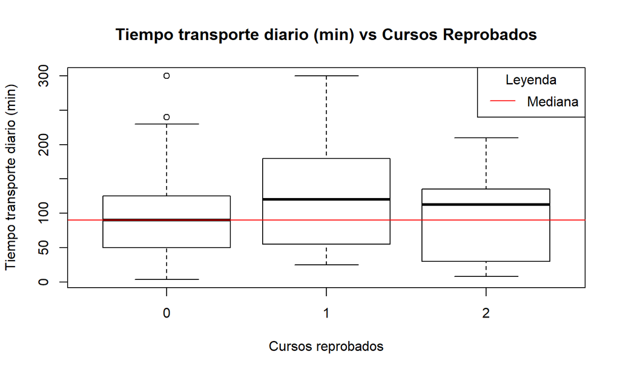

```
##
##  Pearson's Chi-squared test
##
## data:  table(DF$Tiempo_Transporte, DF$NroReprobados)
## X-squared = 86.121, df = 72, p-value = 0.1225
```

## ¿Existe alguna relación las horas semanales de transporte con la calificación que le pone el alumno al transporte?

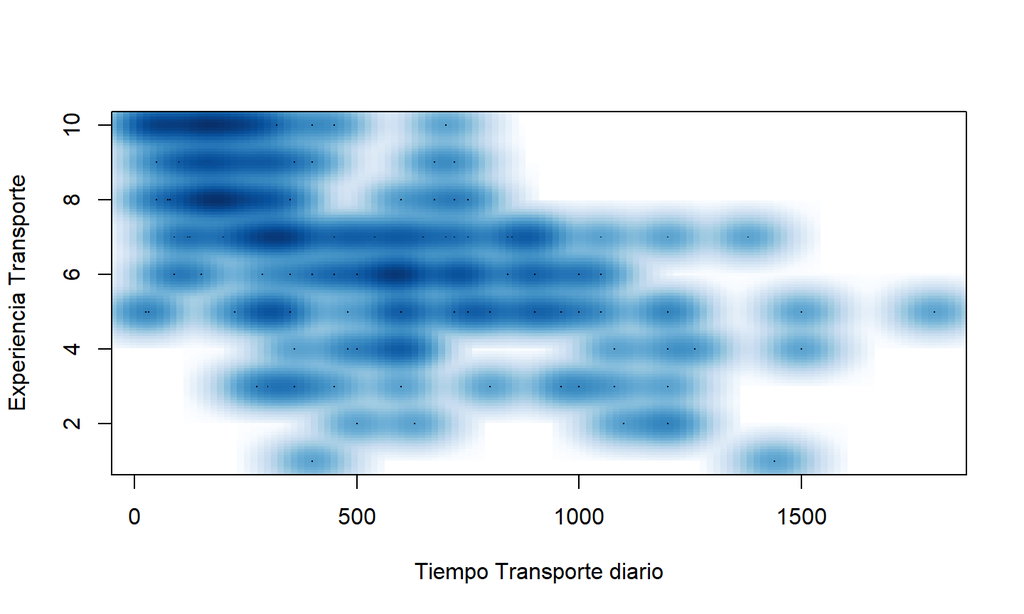

```
##
##  Pearson's Chi-squared test
##
## data:  table(DF$Transporte_Semanal, DF$Calificacion)
## X-squared = 626.24, df = 504, p-value = 0.0001608
```

## ¿Existe alguna relación entre las horas que se transportan semanalmente y las horas que duermen los estudiantes?

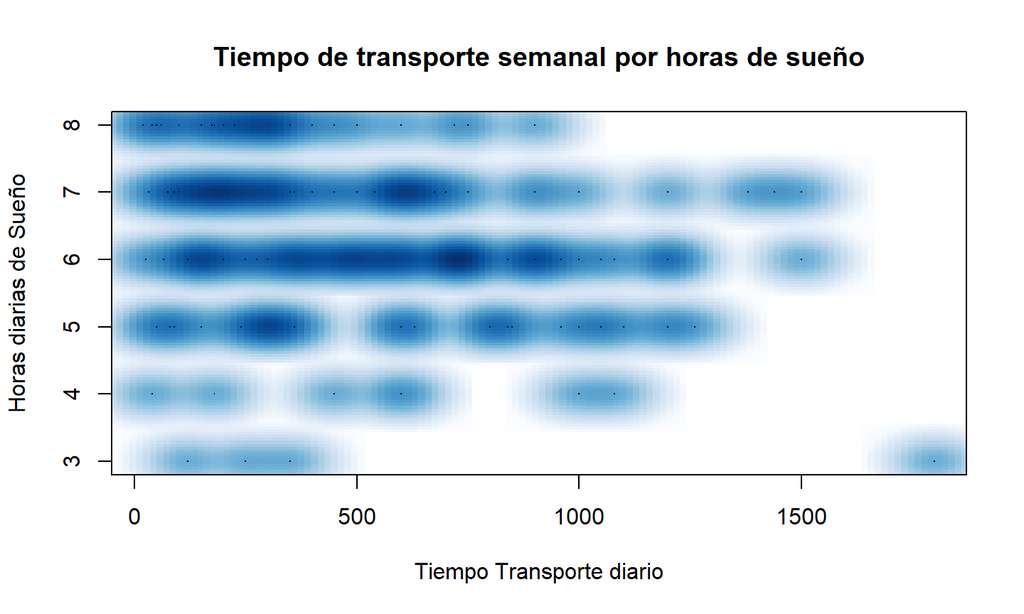

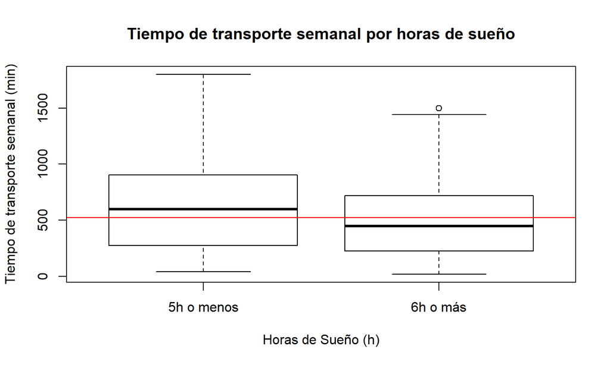

```
##
##  One Sample t-test
##
## data:  dmenos$Transporte_Semanal
## t = 2.1532, df = 42, p-value = 0.9815
## alternative hypothesis: true mean is less than 450
## 95 percent confidence interval:
##      -Inf 694.3868
## sample estimates:
## mean of x
##  587.2093
```

## ¿Existe una relación entre el número de horas que duermen los estudiantes y el nivel de estrés que presentan?

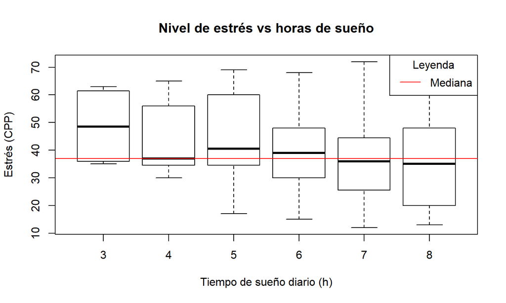

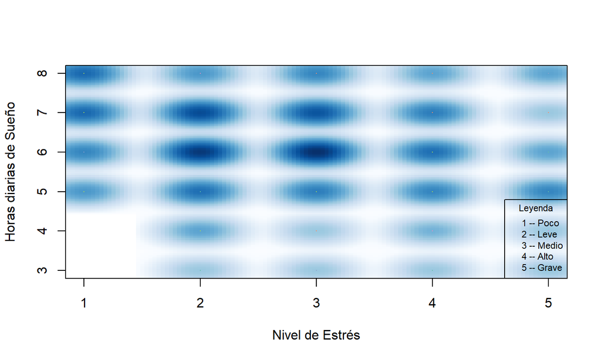

```
##    Min. 1st Qu.  Median    Mean 3rd Qu.    Max.
##   3.000   5.000   6.000   5.907   7.000   8.000
```

```
##
##  One Sample t-test
##
## data:  Estresmayor$Tiempo_Dormir
## t = -0.00011518, df = 42, p-value = 0.5
## alternative hypothesis: true mean is greater than 5.907
## 95 percent confidence interval:
##  5.56737     Inf
## sample estimates:
## mean of x
##  5.906977
```

## Relaciones potencialmente interesantes entre variables

## Relaciones potencialmente interesantes entre variables

1. Nivel de Estrés y Horas de Sueño diarias
2. Tiempo de Transporte diario y Número de Cursos reprobados
3. Tiempo de Transporte semanal y Horas de Sueño diarias
4. Tiempo de Transporte semanal y Calificación del Transporte

## Regresión

## 1. Nivel de Estrés y Horas de Sueño diarias

```
##
## Call:
## lm(formula = DF$Tiempo_Dormir ~ DF$Estres)
##
## Residuals:
##     Min      1Q  Median      3Q     Max
## -3.3157 -0.5190 -0.0809  0.7610  2.3527
##
## Coefficients:
##              Estimate Std. Error t value Pr(>|t|)
## (Intercept)  6.948073   0.251176   27.66   <2e-16 ***
## DF$Estres   -0.018067   0.005983   -3.02   0.0029 **
## ---
## Signif. codes:  0 '***' 0.001 '**' 0.01 '*' 0.05 '.' 0.1 ' ' 1
##
## Residual standard error: 1.128 on 178 degrees of freedom
## Multiple R-squared:  0.04874,    Adjusted R-squared:  0.04339
## F-statistic:  9.12 on 1 and 178 DF,  p-value: 0.002901
```

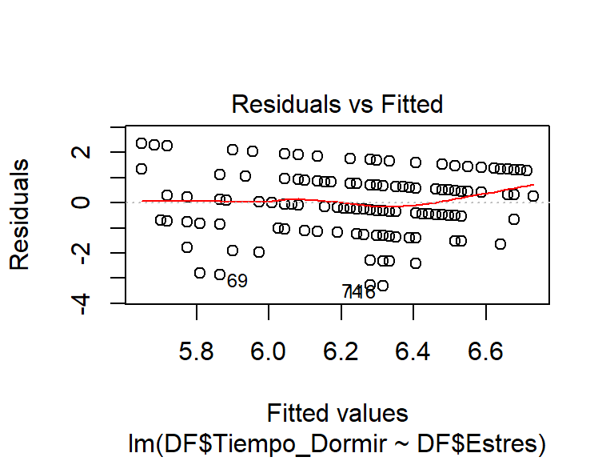

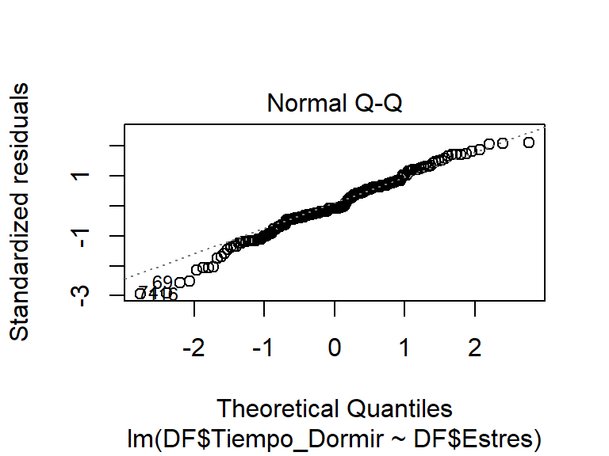

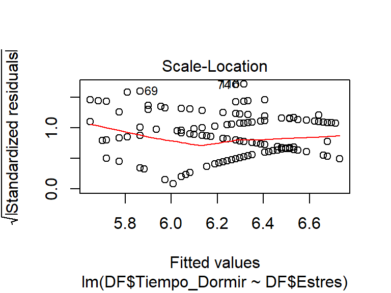

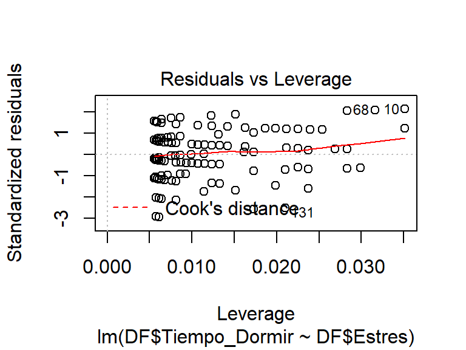

```
##
##  One Sample t-test
##
## data:  Estres_Sueño$coefficients
## t = 0.99481, df = 1, p-value = 0.5017
## alternative hypothesis: true mean is not equal to 0
## 95 percent confidence interval:
##  -40.79159  47.72160
## sample estimates:
## mean of x
##  3.465003
```

## 2. Tiempo de Transporte diario y Número de Cursos reprobados

```
##
## Call:
## lm(formula = DF$NroReprobados ~ DF$Tiempo_Transporte)
##
## Residuals:
##      Min       1Q   Median       3Q      Max
## -0.44239 -0.31697 -0.27517 -0.03771  1.76107
##
## Coefficients:
##                       Estimate Std. Error t value Pr(>|t|)
## (Intercept)          0.2333601  0.0766166   3.046  0.00267 **
## DF$Tiempo_Transporte 0.0006968  0.0006155   1.132  0.25912
## ---
## Signif. codes:  0 '***' 0.001 '**' 0.01 '*' 0.05 '.' 0.1 ' ' 1
##
## Residual standard error: 0.5697 on 178 degrees of freedom
## Multiple R-squared:  0.007149,   Adjusted R-squared:  0.001571
## F-statistic: 1.282 on 1 and 178 DF,  p-value: 0.2591
```

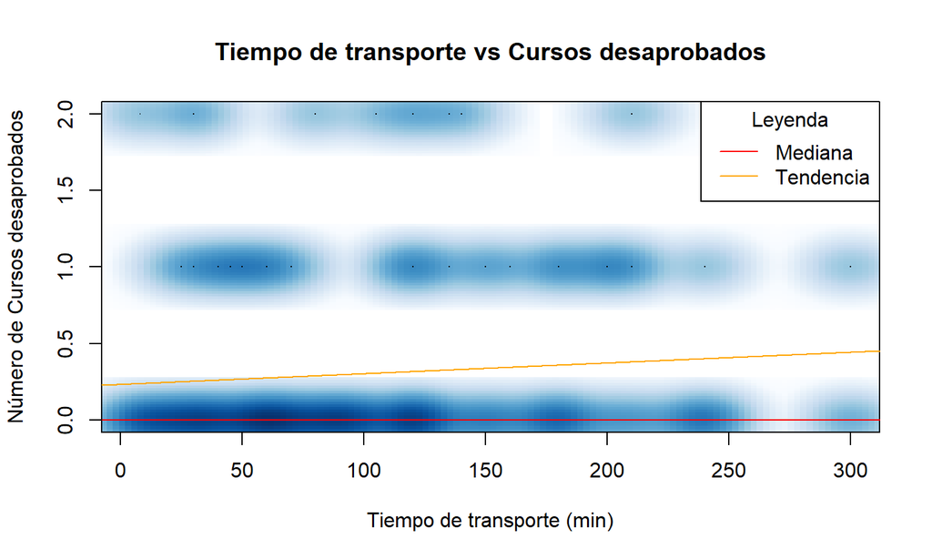

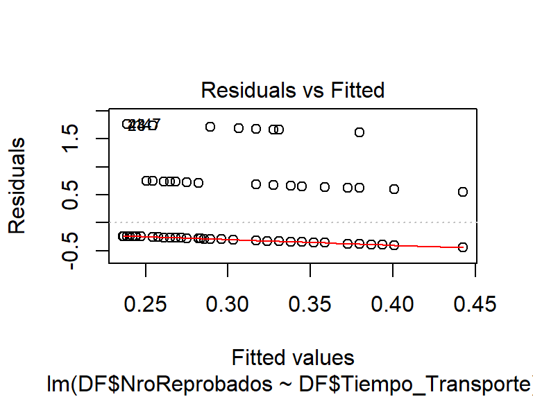

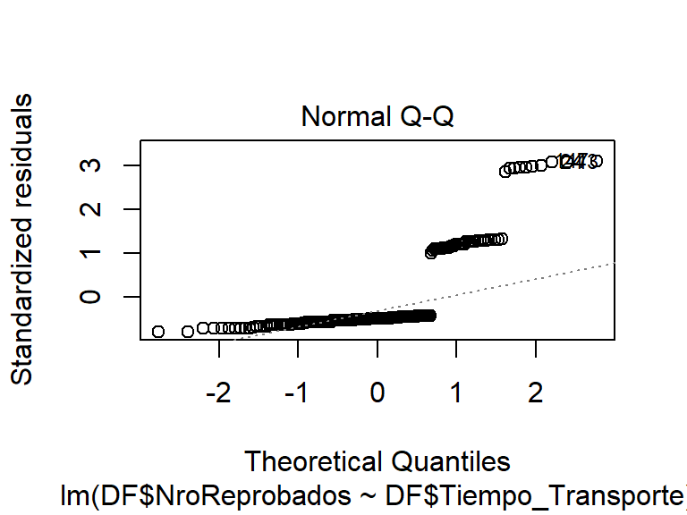

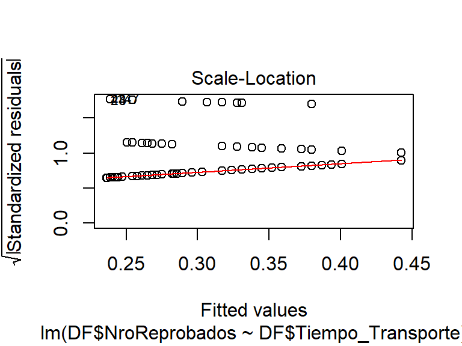

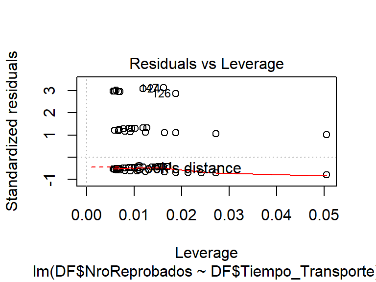

```
##
##  One Sample t-test
##
## data:  Trans_Repr$coefficients
## t = 1.006, df = 1, p-value = 0.4981
## alternative hypothesis: true mean is not equal to 0
## 95 percent confidence interval:
##  -1.361106  1.595163
## sample estimates:
## mean of x
## 0.1170284
```

## 3. Tiempo de Transporte semanal y Horas de Sueño diarias

```
##
## Call:
## lm(formula = DF$Tiempo_Dormir ~ DF$Transporte_Semanal)
##
## Residuals:
##     Min      1Q  Median      3Q     Max
## -3.5199 -0.5296 -0.0410  0.7887  2.0334
##
## Coefficients:
##                         Estimate Std. Error t value Pr(>|t|)
## (Intercept)            6.6049783  0.1480073  44.626  < 2e-16 ***
## DF$Transporte_Semanal -0.0007094  0.0002325  -3.051  0.00263 **
## ---
## Signif. codes:  0 '***' 0.001 '**' 0.01 '*' 0.05 '.' 0.1 ' ' 1
##
## Residual standard error: 1.128 on 178 degrees of freedom
## Multiple R-squared:  0.04969,    Adjusted R-squared:  0.04435
## F-statistic: 9.307 on 1 and 178 DF,  p-value: 0.002633
```

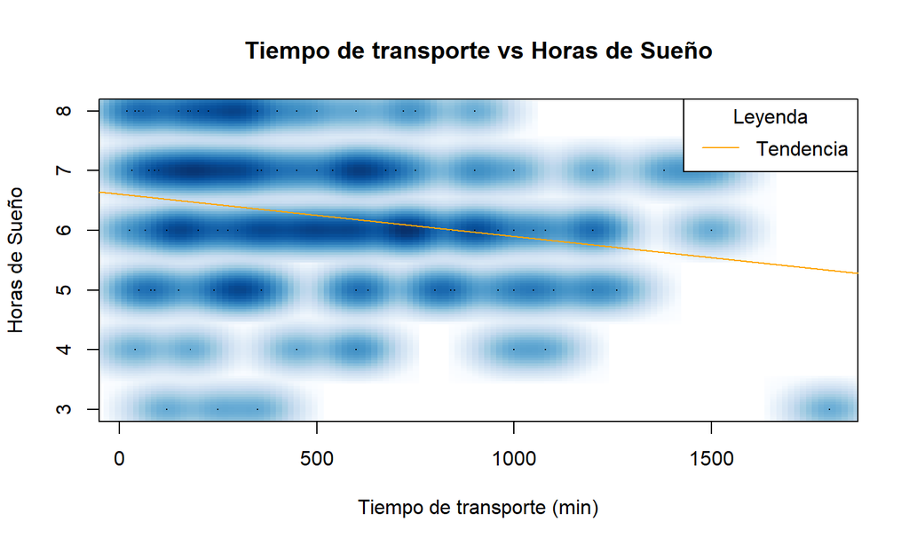

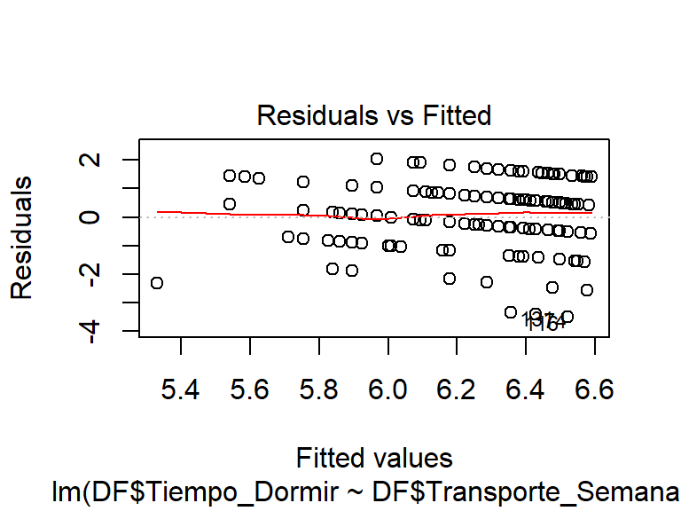

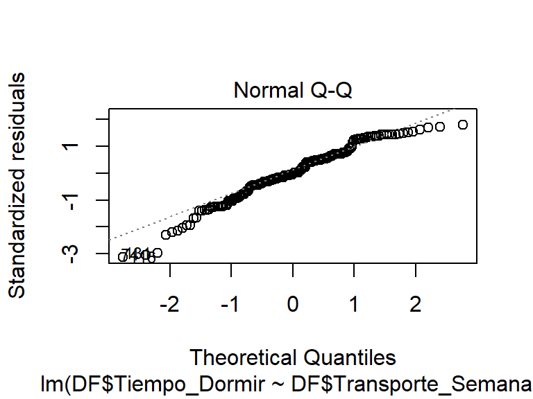

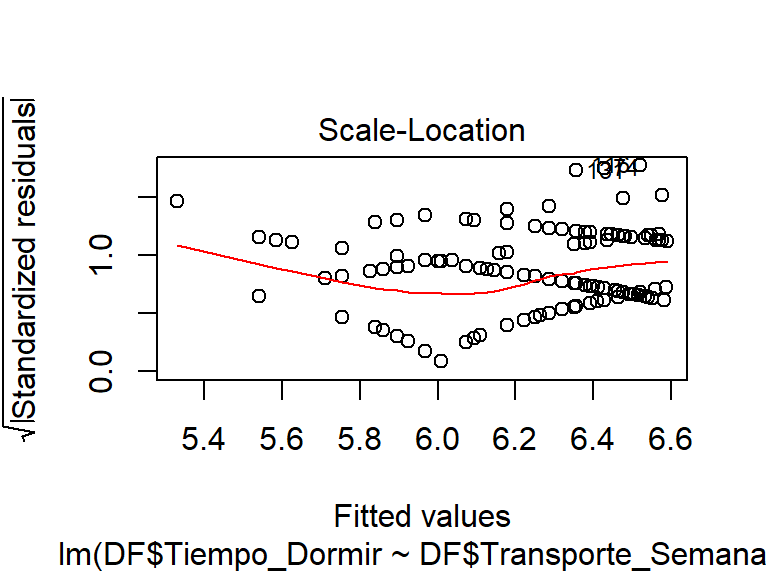

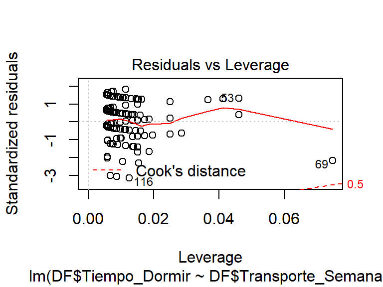

```
##
##  One Sample t-test
##
## data:  Trans_Sueño$coefficients
## t = 0.99979, df = 1, p-value = 0.5001
## alternative hypothesis: true mean is not equal to 0
## 95 percent confidence interval:
##  -38.66448  45.26874
## sample estimates:
## mean of x
##  3.302134
```

## 4. Tiempo de Transporte semanal y Calificación del Transporte

```
##
## Call:
## lm(formula = DF$Calificacion ~ DF$Transporte_Semanal)
##
## Residuals:
##     Min      1Q  Median      3Q     Max
## -5.9840 -0.9365  0.1790  1.3831  4.0128
##
## Coefficients:
##                         Estimate Std. Error t value Pr(>|t|)
## (Intercept)            8.3130122  0.2434415  34.148  < 2e-16 ***
## DF$Transporte_Semanal -0.0033226  0.0003825  -8.688 2.35e-15 ***
## ---
## Signif. codes:  0 '***' 0.001 '**' 0.01 '*' 0.05 '.' 0.1 ' ' 1
##
## Residual standard error: 1.855 on 178 degrees of freedom
## Multiple R-squared:  0.2978, Adjusted R-squared:  0.2938
## F-statistic: 75.48 on 1 and 178 DF,  p-value: 2.349e-15
```

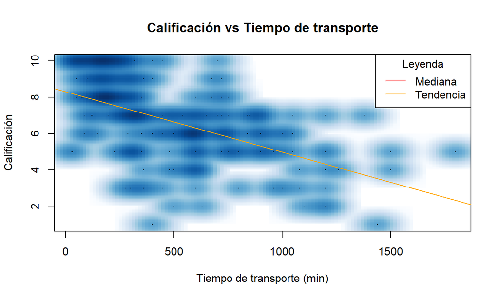

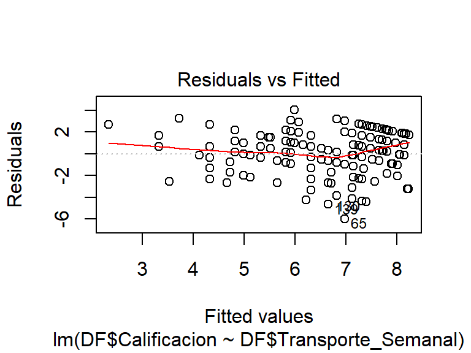

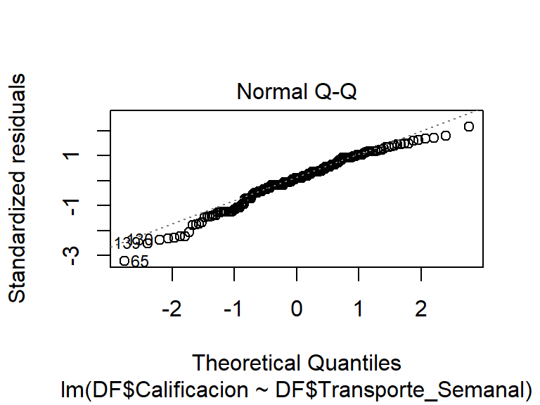

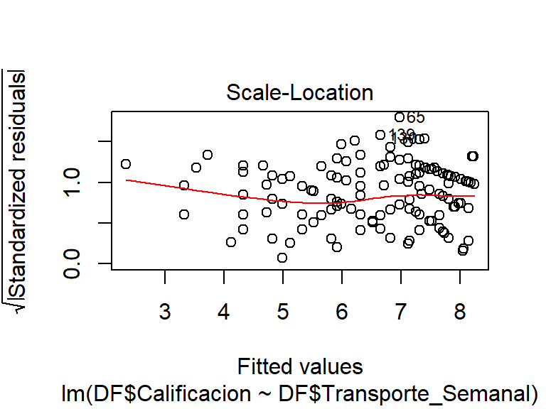

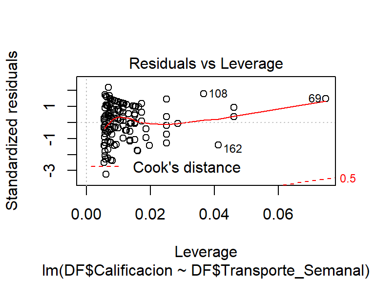

```
##
##  One Sample t-test
##
## data:  Trans_Calif$coefficients
## t = 0.9992, df = 1, p-value = 0.5003
## alternative hypothesis: true mean is not equal to 0
## 95 percent confidence interval:
##  -48.67968  56.98937
## sample estimates:
## mean of x
##  4.154845
```

## Horas de Sueño en función del Nivel de Estres y el Tiempo de Transporte Semanal

```
##
## Call:
## lm(formula = DF$Tiempo_Dormir ~ DF$Transporte_Semanal + DF$Estres)
##
## Residuals:
##     Min      1Q  Median      3Q     Max
## -3.5252 -0.6516 -0.0283  0.6657  2.2137
##
## Coefficients:
##                         Estimate Std. Error t value Pr(>|t|)
## (Intercept)            7.0902015  0.2552343  27.779   <2e-16 ***
## DF$Transporte_Semanal -0.0005621  0.0002383  -2.358   0.0194 *
## DF$Estres             -0.0142156  0.0061289  -2.319   0.0215 *
## ---
## Signif. codes:  0 '***' 0.001 '**' 0.01 '*' 0.05 '.' 0.1 ' ' 1
##
## Residual standard error: 1.114 on 177 degrees of freedom
## Multiple R-squared:  0.07772,    Adjusted R-squared:  0.0673
## F-statistic: 7.458 on 2 and 177 DF,  p-value: 0.000777
```

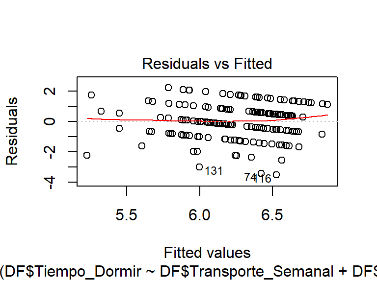

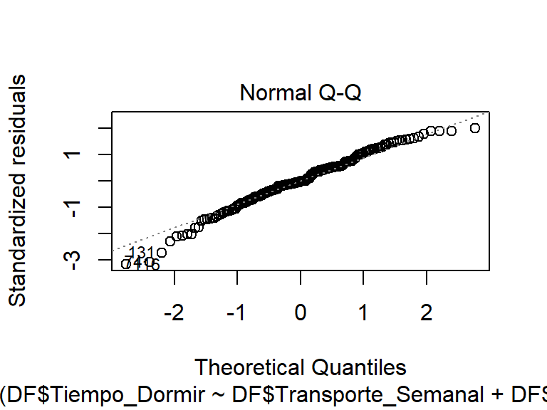

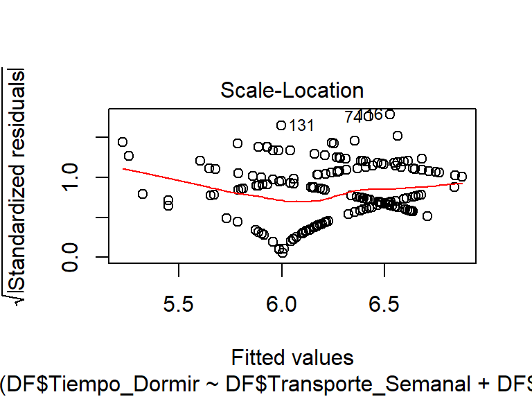

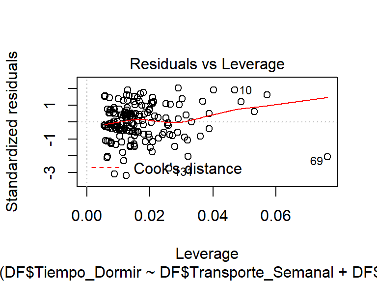

```
##
##  One Sample t-test
##
## data:  R_Sueño$coefficients
## t = 0.99688, df = 2, p-value = 0.4239
## alternative hypothesis: true mean is not equal to 0
## 95 percent confidence interval:
##  -7.821028 12.537977
## sample estimates:
## mean of x
##  2.358475
```

## Calificación en función del Tiempo de Transporte Semanal y el principal Medio de Transporte

```
##
## Call:
## lm(formula = DF$Calificacion ~ DF$Transporte_Semanal + DF$M1)
##
## Residuals:
##    Min     1Q Median     3Q    Max
## -6.293 -1.070  0.202  1.169  3.701
##
## Coefficients:
##                                      Estimate Std. Error t value Pr(>|t|)
## (Intercept)                         9.5057764  0.5132635  18.520  < 2e-16 ***
## DF$Transporte_Semanal              -0.0024889  0.0004365  -5.701 5.11e-08 ***
## DF$M1Carro Particular              -1.2166960  0.5790292  -2.101  0.03708 *
## DF$M1Combi / micro                 -2.5266152  0.6035355  -4.186 4.53e-05 ***
## DF$M1Metropolitano / Corredor rojo -2.0044517  0.6688324  -2.997  0.00313 **
## DF$M1Otro                           0.5440012  1.8388302   0.296  0.76771
## DF$M1Taxi                          -1.1674206  0.6390912  -1.827  0.06949 .
## DF$M1Tren electrico                -1.6131165  1.0449319  -1.544  0.12450
## DF$M1Voy caminando                 -1.2410374  0.8831574  -1.405  0.16177
## ---
## Signif. codes:  0 '***' 0.001 '**' 0.01 '*' 0.05 '.' 0.1 ' ' 1
##
## Residual standard error: 1.766 on 171 degrees of freedom
## Multiple R-squared:  0.3884, Adjusted R-squared:  0.3598
## F-statistic: 13.58 on 8 and 171 DF,  p-value: 3.804e-15
```